# JIVE Integration (Dataset 1)

Joey Hastings

2023-03-01

# Load Packages

```r
library(tictoc)
library(tidyverse)
library(cowplot)
library(ggExtra)
library(ggthemes)

library(splatter)
library(scater)
library(scran)
library(r.jive)
library(Seurat)
library(factoextra)
library(SLIDE)
library(RSpectra)
library(lme4)

library(kBET) # kBET
library(cluster) # ASW
library(lisi) # LISI
library(mclust) # ARI

source("PVCA.R")

theme_set(theme_few())
```

# Simulation 1

## Generate Cell Counts

- Three cell types/groups (unbalanced)
- Two batches (balanced)
- Small dropout

```r
# Parameters that remain the same for all cell types
nGenes <- 5000
method = "single"
dropout.type = "experiment"
dropout.shape = -1
verbose = FALSE
```

```r
tic("Data Simulation")
sim1 <- splatSimulate(
  # Parameters to tweak in each simulation
  batchCells = c(500, 500),
  batch.facLoc = 0.2,
  batch.facScale = 0.1,
  dropout.mid = 0.05,
  # Parameters to remain the same
  nGenes = nGenes,
  method = "groups",
  seed = 1,
  dropout.type = dropout.type,
  dropout.shape = dropout.shape,
  group.prob = c(0.6, 0.3, 0.1),
  de.prob = c(0.01, 0.1, 0.5),
  de.downProb = c(0.01, 0.4, 0.9),
  de.facLoc = c(0.6, 1, 0.2),
  de.facScale = c(0.1, 0.4, 0.8),
  verbose = verbose
  )
toc()
```

```
## Data Simulation: 4.79 sec elapsed
```

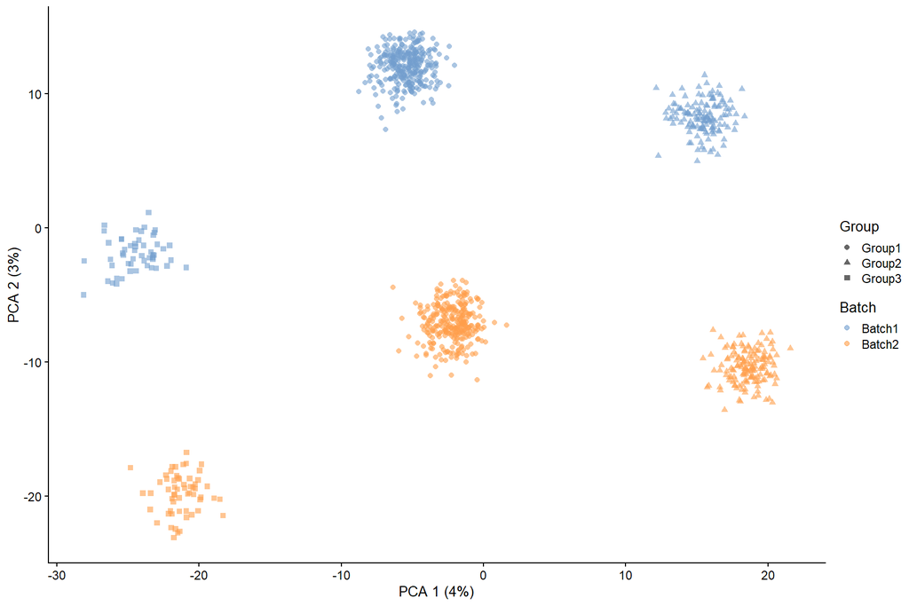

```r
sim1 <- logNormCounts(sim1)
sim1 <- addPerCellQC(sim1)
n.features <- colData(sim1)$detected
colData(sim1)$PctZero <- 100 * (1 - n.features/nrow(sim1))

# Dimension reduction visualization
set.seed(1)
sim1 <- runPCA(sim1, ncomponents = 30, ntop = 2000)
sim1 <- runTSNE(sim1)
sim1 <- runUMAP(sim1)
orig_p1 <- plotPCA(sim1, color_by = "Batch", shape_by = "Group")
orig_p2 <- plotTSNE(sim1, color_by = "Batch", shape_by = "Group")
orig_p3 <- plotUMAP(sim1, color_by = "Batch", shape_by = "Group")

orig_p1
```

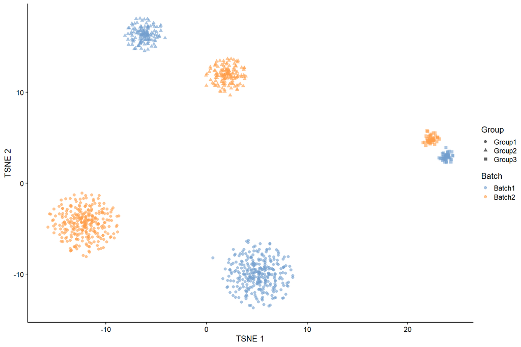

```r
orig_p2
```

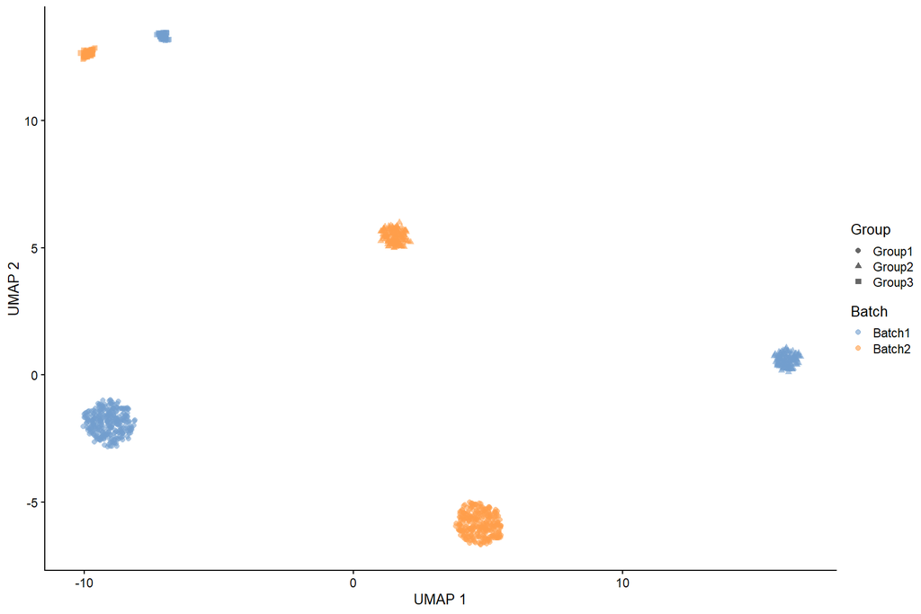

```r
orig_p3
```

```r
# orig_marg <- ggMarginal(orig_p1, type = "density", groupColour = TRUE, groupFill = TRUE)

# orig_marg
```

## Separate Batches

```r
batches <- sim1$Batch
# Frequency of batches in simulation
table(batches)
```

```
## batches
## Batch1 Batch2
##    500    500
```

```r
groups <- sim1$Group
# Frequency of cell types in simulation
table(groups)
```

```
## groups
## Group1 Group2 Group3
##    606    284    110
```

```r
rawcounts <- counts(sim1)
dim(rawcounts)
```

```
## [1] 5000 1000
```

```r
b1 <- rawcounts[, batches == "Batch1"]
grp_b1 <- groups[batches == "Batch1"]
# Dimension of batch 1
dim(b1)
```

```
## [1] 5000  500
```

```r
# Frequency of cell types in batch 1
table(grp_b1)
```

```
## grp_b1
## Group1 Group2 Group3
##    312    136     52
```

```r
b2 <- rawcounts[, batches == "Batch2"]
grp_b2 <- groups[batches == "Batch2"]
# Dimension of batch 2
dim(b2)
```

```
## [1] 5000  500
```

```r
# Frequency of cell types in batch 2
table(grp_b2)
```

```
## grp_b2
## Group1 Group2 Group3
##    294    148     58
```

## PVCA

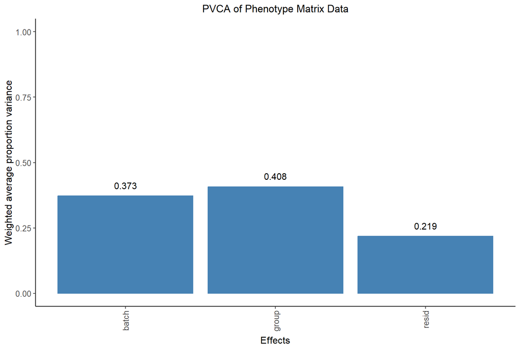

```r
# Perform PVCA for 10 random samples of size 1000 (more computationally efficient)
pvca.res <- matrix(nrow = 10, ncol = 3)
meta <- cbind(batch = batches, group = groups)

for (i in 1:10){
  sample <- sample(1:ncol(rawcounts), 1000, replace = FALSE)
  pvca.res[i, ] <- PVCA(rawcounts[, sample], meta[sample, ], threshold = 0.6, inter = FALSE)
}

# Average effect size across samples
pvca.means <- colMeans(pvca.res)
names(pvca.means) <- c(colnames(meta), "resid")

# Plot PVCA
pvca.plot <- PlotPVCA(pvca.means, "PVCA of Phenotype Matrix Data")
pvca.plot
```

## JIVE

This time we transpose the matrices so that the common genes ($n$ = 5000) are the columns and the cells are the rows:

```r
sim1_data <- NULL
sim1_data$Batch1 <- t(b1)
sim1_data$Batch2 <- t(b2)

set.seed(1)

# Given Ranks
tic("JIVE Analysis (Given Ranks: 5, 7, 7)")
JIVE_results_577 <- jive(
  sim1_data,
  rankJ = 5,
  rankA = c(7, 7),
  method = "given",
  maxiter = 3000
)
toc()
# JIVE Analysis (Given Ranks: 5, 7, 7): 18650.76 sec elapsed
saveRDS(JIVE_results_577, file = "data/JIVE_dataset1_given_5_7_7.rds")
```

Summary of estimated ranks and variance explained by joint/individual/residual for each approach:

```r
# JIVE_results <- readRDS(file = "data/JIVE_dataset1_given_5_7_7.rds")
# JIVE_results <- readRDS(file = "data/JIVE_dataset1_speedup.rds")
JIVE_results <- readRDS(file = "data/JIVE_v2_dataset1.rds")
summary(JIVE_results)
```

```
## $Method
## [1] "given"
##
## $Ranks
##      Source   Rank
## [1,] "Joint"  "10"
## [2,] "Batch1" "15"
## [3,] "Batch2" "15"
##
## $Variance
##            Batch1 Batch2
## Joint       0.892  0.952
## Individual  0.076  0.014
## Residual    0.032  0.034
```

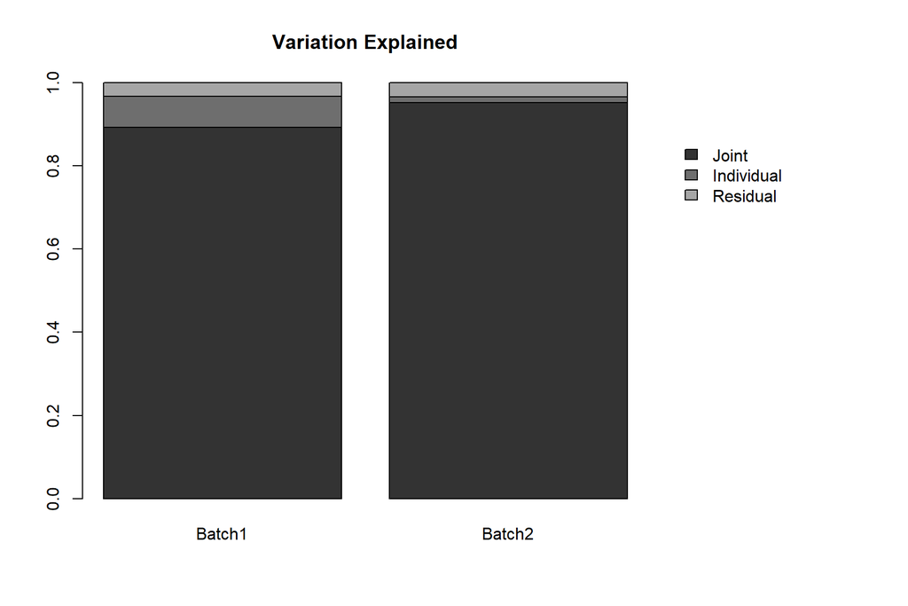

```r
plot(JIVE_results)
```

### Visualization using PCA

Visualize the principal components of the joint portion of the JIVE decomposition:

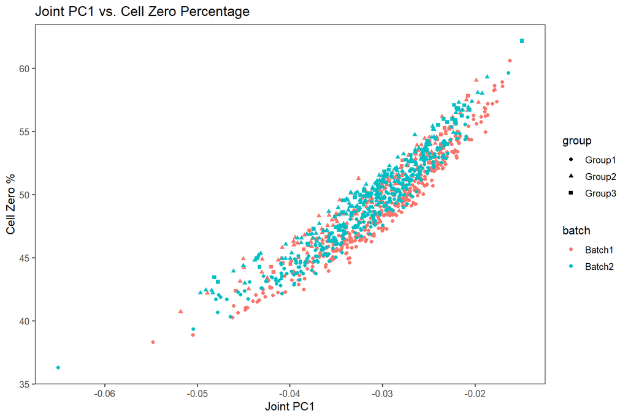

```r
joint <- do.call(rbind, JIVE_results$joint)
indiv <- do.call(rbind, JIVE_results$individual)

# SVD
# only the most variable genes?
# ntop <- 2000
# ncomp <- 30
# var_genes_indices <- tail(sort(colWeightedVars(joint), index.return = T)$ix, ntop)
# joint_svd <- svd(joint[, var_genes_indices], nu = ncomp, nv = ncomp)

joint_svd <- svd(joint)
joint_pc <- joint_svd$u %>%
  as.data.frame() %>%
  select(1:5) %>%
  mutate(
    Batch = batches,
    Group = c(grp_b1, grp_b2)
  )

joint_zeros <- data.frame(
  joint_pc1 = joint_pc[, 1],
  pct_zero = colData(sim1)$PctZero,
  batch = batches,
  group = c(grp_b1, grp_b2)
)

joint_pc1_zeros <- ggplot(data = joint_zeros) +
  geom_point(aes(x = joint_pc1, y = pct_zero, color = batch, shape = group)) +
  labs(x = "Joint PC1", y = "Cell Zero %", title = "Joint PC1 vs. Cell Zero Percentage")

joint_pc1_zeros
```

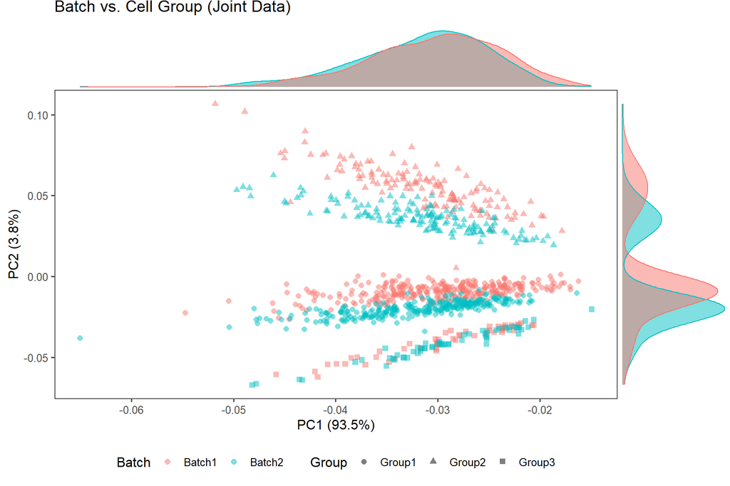

```r
joint_final <- joint

# https://genomicsclass.github.io/book/pages/pca_svd.html
svd_var_expl <- round(100 * (joint_svd$d^2 / sum(joint_svd$d^2)), digits = 1)

# Plot
p <- ggplot(data = joint_pc) +
  geom_point(
    aes(x = V1, y = V2, color = Batch, shape = Group),
    alpha = 0.5, size = 2
  ) +
  labs(
    x = paste0("PC1 (", svd_var_expl[1], "%)"),
    y = paste0("PC2 (", svd_var_expl[2], "%)")
    ) +
  theme(legend.position = "bottom") +
  labs(title = "Batch vs. Cell Group (Joint Data)")

marg_p <- ggMarginal(p, type = "density", groupColour = TRUE, groupFill = TRUE)
marg_p
```

### Visualization using `SCE`

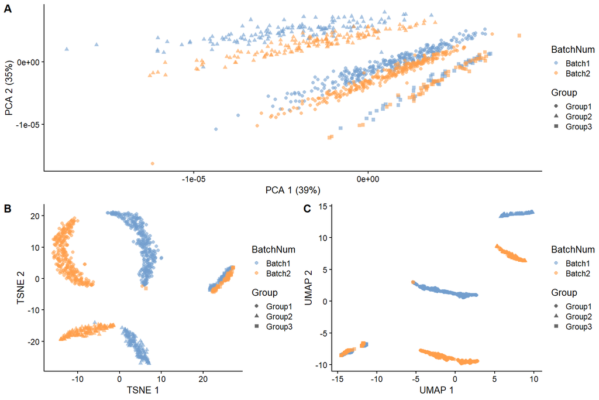

```r
JIVE_joint_b1_SCE <- SingleCellExperiment(list(logcounts = t(JIVE_results[["joint"]][[1]])))
colData(JIVE_joint_b1_SCE)$Group <- grp_b1
colData(JIVE_joint_b1_SCE)$BatchNum <- "Batch1"

JIVE_joint_b2_SCE <- SingleCellExperiment(list(logcounts = t(JIVE_results[["joint"]][[2]])))
colData(JIVE_joint_b2_SCE)$Group <- grp_b2
colData(JIVE_joint_b2_SCE)$BatchNum <- "Batch2"

JIVE_joint_SCE <- cbind(JIVE_joint_b1_SCE, JIVE_joint_b2_SCE)

set.seed(1)
# Original PCA based on joint matrices for each batch
JIVE_joint_SCE <- runPCA(JIVE_joint_SCE, ncomponents = 30, ntop = 2000)

# t-SNE based on original PC
JIVE_joint_SCE <- runTSNE(JIVE_joint_SCE)

# UMAP based on original PC
JIVE_joint_SCE <- runUMAP(JIVE_joint_SCE)

dr1 <- plotReducedDim(JIVE_joint_SCE, dimred = "PCA", color_by = "BatchNum", shape_by = "Group")
dr2 <- plotReducedDim(JIVE_joint_SCE, dimred = "TSNE", color_by = "BatchNum", shape_by = "Group")
dr3 <- plotReducedDim(JIVE_joint_SCE, dimred = "UMAP", color_by = "BatchNum", shape_by = "Group")

# first align the top-row plot (dr1) with the left-most plot of the
# bottom row (dr2)
plots <- align_plots(dr1, dr2, align = 'v', axis = 'l')
# then build the bottom row
bottom_row <- plot_grid(plots[[2]], dr3, labels = c('B', 'C'), label_size = 12)

# then combine with the top row for final plot
dr_all <- plot_grid(plots[[1]], bottom_row, labels = c('A', ''), label_size = 12, ncol = 1)
dr_all
```

```r
###

# # First PC removed
# reducedDim(JIVE_joint_SCE, type = "PCA_alt") <- joint_final
#
# # t-SNE based on modified PCA
# JIVE_joint_SCE <- runTSNE(JIVE_joint_SCE, dimred = "PCA_alt", name = "TSNE_alt")
#
# # UMAP based on modified PCA
# JIVE_joint_SCE <- runUMAP(JIVE_joint_SCE, dimred = "PCA_alt", name = "UMAP_alt")
#
# dr1_alt <- plotReducedDim(JIVE_joint_SCE, dimred = "PCA_alt", color_by = "BatchNum", shape_by = "Group")
# dr2_alt <- plotReducedDim(JIVE_joint_SCE, dimred = "TSNE_alt", color_by = "BatchNum", shape_by = "Group")
# dr3_alt <- plotReducedDim(JIVE_joint_SCE, dimred = "UMAP_alt", color_by = "BatchNum", shape_by = "Group")
#
# plots <- align_plots(dr1_alt, dr2_alt, align = 'v', axis = 'l')
# # then build the bottom row
# bottom_row <- plot_grid(plots[[2]], dr3_alt, labels = c('E', 'F'), label_size = 12)
#
# # then combine with the top row for final plot
# dr_alt_all <- plot_grid(plots[[1]], bottom_row, labels = c('D', ''), label_size = 12, ncol = 1)
# dr_alt_all
```

### Calculate kBET

- Sub-sample data at varying percentages
  - 5%, 10%, 15%, 20%, 25%
  - Stratified sampling so that each batch has the same number of cells selected
    - E.g., assume 2 batches, sampling 10% of 1000 cells = 100 cells: sample 50 cells from each batch
- Calculate kBET rejection rates at each percentage
  - **Lower** RR indicate well-mixed batches
  - **Higher** RR indicate poorly-mixed batches

```r
# data: a matrix (rows: samples, columns: features (genes))
data <- svds(joint_final, k = 30)$u

# batch: vector or factor with batch label of each cell
batch <- batches

sample_size <- seq(0.05, 0.25, 0.05)
rejection_rate <- list()

set.seed(1)
for (i in sample_size) {
  k <- floor(nrow(data) * i)

  batch.estimate <- kBET(data, batch, k0 = k, plot = F, do.pca = F)

  if (class(batch.estimate) == "list") {
    rejection_rate[[which(sample_size == i)]] <- batch.estimate$summary %>%
      rownames_to_column(var = "statistic") %>%
      mutate(sample_size = i) %>%
      select(sample_size, statistic, kBET_rr = kBET.observed)
  }
}

all_rr <- bind_rows(rejection_rate) %>%
  mutate(group = "All") %>%
  pivot_wider(id_cols = c(group, sample_size), names_from = statistic, values_from = kBET_rr)

p_kBET_all <- all_rr %>%
  ggplot(aes(x = sample_size, y = `50%`)) +
  # geom_line(aes(y = `97.5%`), color = "darkgray", linetype = "dashed") +
  # geom_line(aes(y = `2.5%`), color = "darkgray", linetype = "dashed") +
  geom_line() +
  # geom_line(aes(y = `97.5%`), color = "darkgray") +
  # geom_linerange(aes(ymin = `2.5%`, ymax = `97.5%`), color = "darkgray", linetype = "dashed") +
  geom_point() +
  scale_x_continuous(labels = scales::percent) +
  labs(x = "% sample size", y = "kBET (rejection rate)")

all_rr %>%
  select(group, sample_size, median_rr = `50%`) %>%
  mutate(method = "JIVE") %>%
  write_csv(file = "output/JIVE_dataset1_kBET_all.csv")
```

Try for one cell type at a time:

```r
# data: a matrix (rows: samples, columns: features (genes))
data <- svds(joint_final, k = 30)$u

# batch: vector or factor with batch label of each cell
batch <- batches

sample_size <- seq(0.05, 0.25, 0.05)
group_rejection_rate <- list()

set.seed(1)
for (group_n in sort(unique(groups))) {
  rejection_rate <- list()
  for (i in sample_size) {
    k <- floor(nrow(data[groups == group_n, ]) * i)

    batch.estimate <- kBET(data[groups == group_n, ], batch[groups == group_n], k0 = k, plot = F, do.pca = F)

    if (class(batch.estimate) == "list") {
      rejection_rate[[which(sample_size == i)]] <- batch.estimate$summary %>%
        rownames_to_column(var = "statistic") %>%
        mutate(group = group_n, sample_size = i) %>%
        select(group, sample_size, statistic, kBET_rr = kBET.observed)
    }
  }
  group_rejection_rate[[group_n]] <- bind_rows(rejection_rate)
}

group_rr <- bind_rows(group_rejection_rate) %>%
  pivot_wider(id_cols = c(group, sample_size), names_from = statistic, values_from = kBET_rr)

p_kBET_group <- group_rr %>%
  ggplot(aes(x = sample_size, y = `50%`, color = group)) +
  # geom_line(aes(y = `97.5%`, color = group), linetype = "dashed") +
  # geom_line(aes(y = `2.5%`, color = group), linetype = "dashed") +
  geom_line() +
  # geom_line(aes(y = `97.5%`), color = "darkgray") +
  # geom_errorbar(aes(ymin = `2.5%`, ymax = `97.5%`, color = group), width = 0.01) +
  geom_point(aes(shape = group)) +
  scale_x_continuous(labels = scales::percent) +
  labs(x = "% sample size", y = "kBET (rejection rate)")

group_rr %>%
  select(group, sample_size, median_rr = `50%`) %>%
  mutate(method = "JIVE") %>%
  write_csv(file = "output/JIVE_dataset1_kBET_bygroup.csv")
```

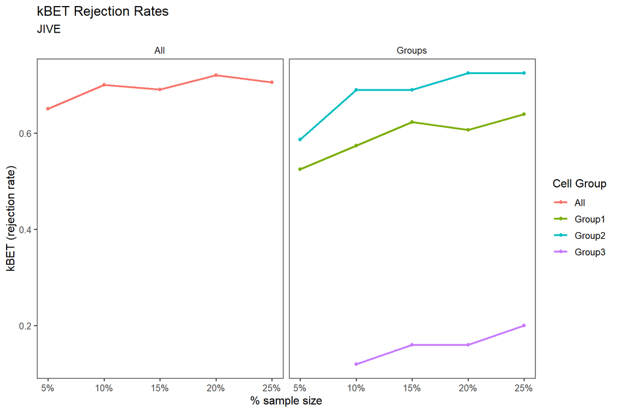

```r
# rejection rates
bind_rows(
  all_rr %>% mutate(type = "All"),
  group_rr %>% mutate(type = "Groups")
  ) %>%
  ggplot(aes(x = sample_size, y = `50%`, color = group)) +
  geom_line(linewidth = 1) +
  geom_point() +
  scale_x_continuous(labels = scales::percent) +
  labs(
    x = "% sample size",
    y = "kBET (rejection rate)",
    color = "Cell Group",
    title = "kBET Rejection Rates",
    subtitle = "JIVE"
  ) +
  #theme(legend.position = "bottom") +
  facet_grid(~ type)
```

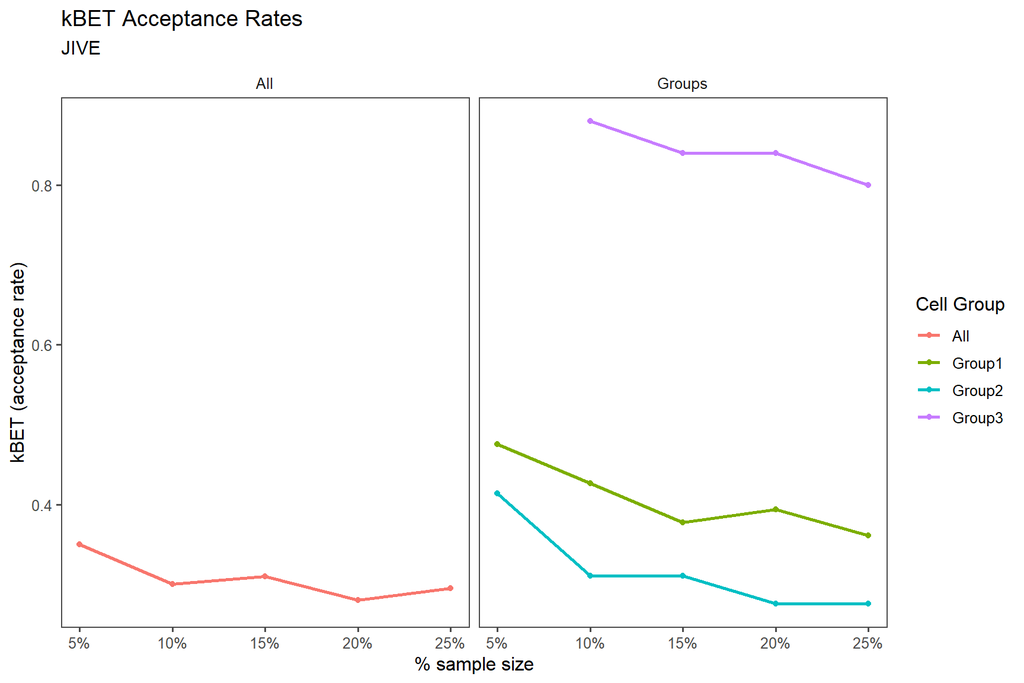

```r
# acceptance rates rates
bind_rows(
  all_rr %>% mutate(type = "All"),
  group_rr %>% mutate(type = "Groups")
  ) %>%
  ggplot(aes(x = sample_size, y = I(1 - `50%`), color = group)) +
  geom_line(linewidth = 1) +
  geom_point() +
  scale_x_continuous(labels = scales::percent) +
  labs(
    x = "% sample size",
    y = "kBET (acceptance rate)",
    color = "Cell Group",
    title = "kBET Acceptance Rates",
    subtitle = "JIVE"
  ) +
  #theme(legend.position = "bottom") +
  facet_grid(~ type)
```

### Calculate Average Silhouette Width

Original batch label and cell types/groups will be considered the clusters to compute $ASW_{batch}$ and $ASW_{group}$

- Compute average silhouette width (ASW) for the first 30 PCs of 80% sub-sample of joint data
  - ASW ranges between -1 and 1
  - Values **close to 1** indicate the cell is well-matched to its cluster (i.e., batch label)
  - Values **close to -1** indicate the cell is **not** well-matched to its cluster (i.e., batch label)
    - We hope to see lower values for $ASW_{batch}$ since it is indicative of well-mixed batches
    - We hope to see higher values for $ASW_{group}$ since it is indicative that distinct cell groups were preserved after batch-mixing
- Repeat `20` times
- Calculate the median ASW from the `20` runs to ensure stability of the measurement

```r
asw_repeat <- 20
npcs <- 30

asw_batch <- list()
asw_group <- list()
subset_prop <- 0.8 # subsample to 80% of the data
subset_size_total <- floor(length(batch) * subset_prop)

set.seed(1)
for (i in 1:asw_repeat) {
  subset_index <-
    data.frame(index = 1:length(batch) , batch = batch) %>%
    slice_sample(n = subset_size_total, replace = F)

  subset_id <- subset_index %>%
    pull(index)

  data_pc <- svds(joint_final[subset_id, ], k = npcs)$u

  dissimilarity_matrix <- daisy(data_pc)

  asw_batch_i <- silhouette(as.integer(factor(batches[subset_id])), dissimilarity_matrix)
  asw_batch[[i]] <- as.data.frame(rbind(summary(asw_batch_i)[["si.summary"]]))

  asw_group_i <- silhouette(as.integer(factor(groups[subset_id])), dissimilarity_matrix)
  asw_group[[i]] <- as.data.frame(rbind(summary(asw_group_i)[["si.summary"]]))
}

all_asw_batch <- bind_rows(asw_batch) %>%
  mutate(cluster = "Batch")

# ASW_batch summary
summary(all_asw_batch$Mean)
```

```
##    Min. 1st Qu.  Median    Mean 3rd Qu.    Max.
## 0.02784 0.02810 0.02824 0.02827 0.02854 0.02875
```

```r
all_asw_group <- bind_rows(asw_group) %>%
  mutate(cluster = "Group")

#ASW_group summary
summary(all_asw_group$Mean)
```

```
##    Min. 1st Qu.  Median    Mean 3rd Qu.    Max.
## 0.04778 0.04876 0.04931 0.04975 0.05099 0.05397
```

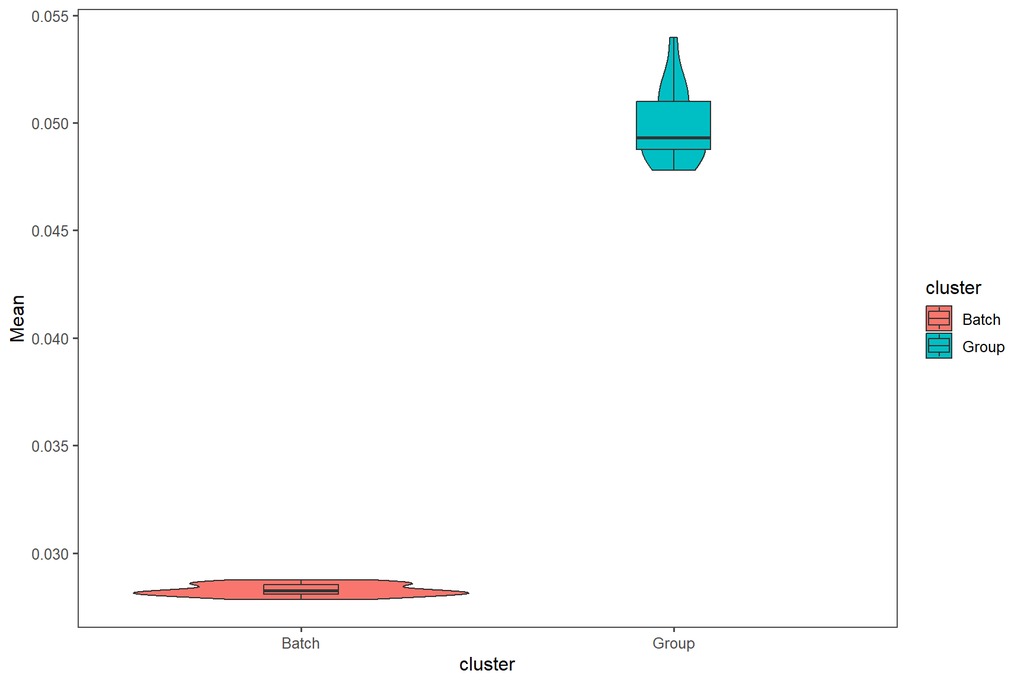

```r
all_asw <- bind_rows(all_asw_batch, all_asw_group)

asw_plot <- ggplot(data = all_asw, aes(x = cluster, y = Mean, fill = cluster)) +
  geom_violin() +
  geom_boxplot(width = 0.2)

asw_plot
```

```r
all_asw %>%
  group_by(cluster) %>%
  summarize(median_asw = median(Mean)) %>%
  mutate(Method = "JIVE") %>%
  write_csv(file = "output/JIVE_dataset1_ASW.csv")
```